# IE 360 Homerwork 2

Yusuf Sina Öztürk

Last edited May 07, 2021

### Introduction

In this work, we will try to forecast Consumer Price Index in footwear and clothing category for one month. We will use linear regression model to forecast in our forecast.

Data that I will use all from [EVDS website](https://evds2.tcmb.gov.tr/index.php?/evds/serieMarket). Data file that I imported from EVDS website have 5 different series. One is the target value which we are going to forecast. Other 4 data series are going to be used as regressors. Their names in data table are;

1. `CPI` - Consumer Price Index for Footwear and Clothing
2. `USD` - USD exchange rates
3. `CCI` - Consumer Confidence Index
4. `Interest` - Interest Rates for personal finance credit
5. `Clothing` - Survey about consideration for spending on Clothing and Footwear Index

I will follow the steps in the order that;

1. Adding a linear Trend regressor
2. Adding Month regressor
3. Adding USD exchange rate regressor
4. Adding all other data series into the model
5. Adding lag variables
6. Forecast

### Importing Data and Manipulation

Getting data from my repository and do manipulations to make ready for forecast

```r
EVDSdata <- read.csv(file = "EVDS.csv")
EVDSdata <- mutate(EVDSdata, Date = ym(ï..Tarih))
EVDSdata = select(EVDSdata, -1)
colnames(EVDSdata) <- c("USD","Interest","CPI","Clothing","CCI","Date")
EVDSdata <- EVDSdata[-c(112:121),]
EVDSdata <- as.data.table(EVDSdata)
EVDSdata[1,]
```

```
##     USD Interest    CPI Clothing  CCI       Date
## 1: 1.84    19.97 131.07   102.57 92.5 2012-01-01
```

As we can see from first row of data, there is 5 data series and their date information.

As I mentioned in Introduction we will try to forecast on `CPI` data series.

In order to visualize how my data that I will work on look like, I plotted `CPI`.

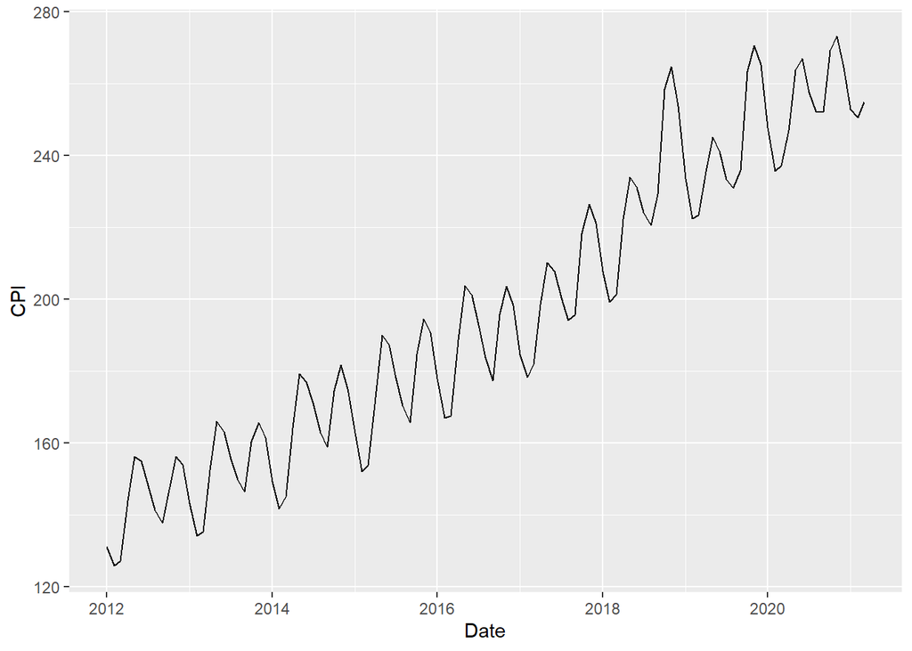

### Trend Regressor

As we can see from plot, obviously there is linear increase in our serie. Therefore, I added ``trend` variable into my data table.

```r
EVDSdata <- as.data.table(EVDSdata)
EVDSdata[,trend:=1:.N, ]
```

Now time to do first model with only using trend regressor.

```r
fit1 = lm(CPI ~trend, data = EVDSdata)
summary(fit1)
```

```
##
## Call:
## lm(formula = CPI ~ trend, data = EVDSdata)
##
## Residuals:
##     Min      1Q  Median      3Q     Max
## -25.290  -9.388   0.291   8.460  35.612
##
## Coefficients:
##              Estimate Std. Error t value Pr(>|t|)
## (Intercept) 128.31164    2.39549   53.56   <2e-16 ***
## trend         1.21417    0.03713   32.70   <2e-16 ***
## ---
## Signif. codes:  0 '***' 0.001 '**' 0.01 '*' 0.05 '.' 0.1 ' ' 1
##
## Residual standard error: 12.53 on 109 degrees of freedom
## Multiple R-squared:  0.9075, Adjusted R-squared:  0.9067
## F-statistic:  1069 on 1 and 109 DF,  p-value: < 2.2e-16
```

Note that our F-statistic value and R-squared values to see whether our model go better or not.

Now, we can do our first prediction using ``fit1` and plot how our predictions look like.

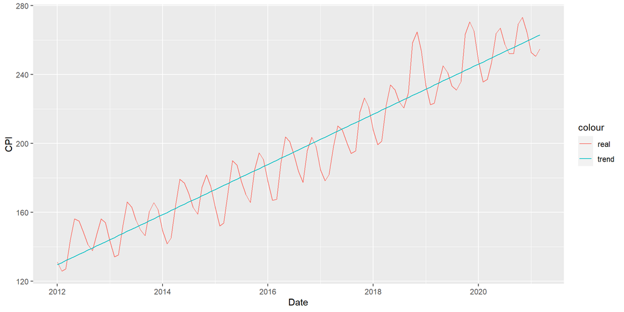

```r
EVDSdata[,pred_trend := predict(fit1,EVDSdata)]

ggplot(EVDSdata,aes(x= Date)) + geom_line(aes(y=CPI,color='real')) + geom_line(aes(y= pred_trend, color='trend'))
```

### Monthly Time Regressor

From plot, we can clearly see that our data has seasonality over months. Therefore, I addded a new variable that represents month information in `mon` variable.

```r
EVDSdata[,mon:=as.character(lubridate::month(Date,label = TRUE))]
```

Now, we are ready to build a new model using month variable addition to trend regressor.

```r
fit2 = lm(CPI~trend+mon,data = EVDSdata)
summary(fit2)
```

```
##
## Call:
## lm(formula = CPI ~ trend + mon, data = EVDSdata)
##
## Residuals:
##     Min      1Q  Median      3Q     Max
## -12.129  -4.401  -1.260   4.333  21.429
##
## Coefficients:
##              Estimate Std. Error t value Pr(>|t|)
## (Intercept) 128.61129    2.70117  47.613  < 2e-16 ***
## trend         1.21258    0.02183  55.534  < 2e-16 ***
## monAug       -6.94588    3.46727  -2.003 0.047909 *
## monDec        8.00490    3.47057   2.307 0.023188 *
## monFeb      -15.81788    3.37953  -4.680 9.19e-06 ***
## monJan       -6.21630    3.37904  -1.840 0.068845 .
## monJul        0.41781    3.46679   0.121 0.904320
## monJun        9.32484    3.46644   2.690 0.008400 **
## monMar      -14.96147    3.38017  -4.426 2.49e-05 ***
## monMay       12.50631    3.46624   3.608 0.000488 ***
## monNov       15.04970    3.46954   4.338 3.50e-05 ***
## monOct        9.08784    3.46864   2.620 0.010192 *
## monSep       -8.93847    3.46789  -2.577 0.011441 *
## ---
## Signif. codes:  0 '***' 0.001 '**' 0.01 '*' 0.05 '.' 0.1 ' ' 1
##
## Residual standard error: 7.353 on 98 degrees of freedom
## Multiple R-squared:  0.9714, Adjusted R-squared:  0.9679
## F-statistic: 277.2 on 12 and 98 DF,  p-value: < 2.2e-16
```

As we can see from the summary, our R-squared values increased significantly. Also most of the month variable had an importance in the model.

To see how improved our model, we do a new prediction with using `fit2`.

```r
EVDSdata[,pred_trend_month:=predict(fit2,EVDSdata)]
```

And plot it:

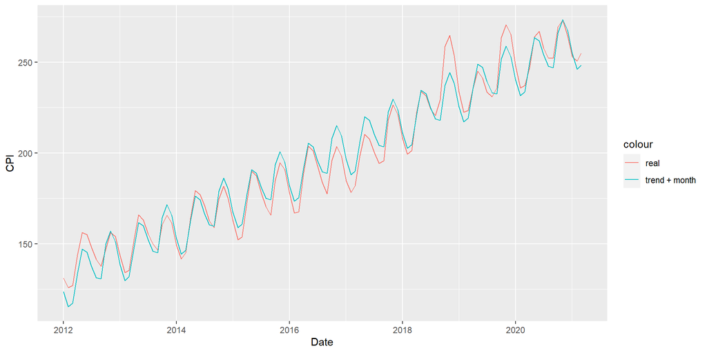

```r
ggplot(EVDSdata,aes(x= Date)) +
  geom_line(aes(y=CPI,color='real')) +
  geom_line(aes(y= pred_trend_month, color='trend + month'))
```

As we can see from the plot, we have a nice prediction curve.

To see do we have correlation in between lags, I used `checkresiduals` function.

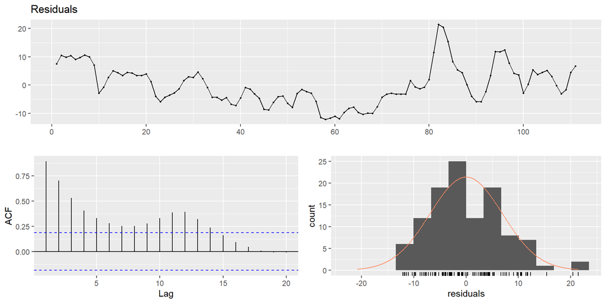

```r
checkresiduals(fit2$residuals)
```

As we can see from ACF graph we still have significantly high correlation between lags.

### USD Exchange Rate Regressor

To see is there any correlation between USD exchange rates and our `fit2` model. I plot Residual vs USD graph.

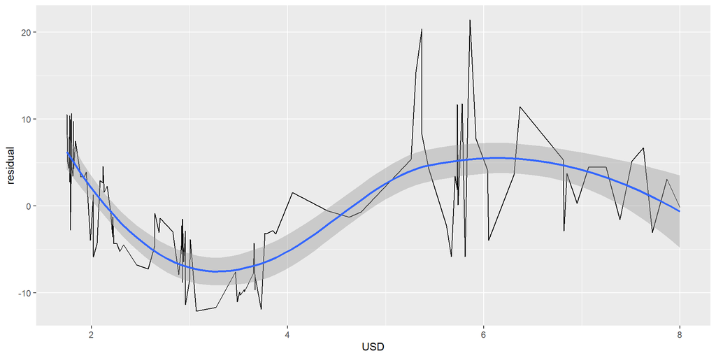

```r
EVDSdata[,residual:=fit2$residuals]

ggplot(EVDSdata,aes(x=USD,y=residual)) +
  geom_line() +
  geom_smooth()
```

As we can see from the plot, there is correlation between our model and USD Exchange rate so we could add this series in our model.

```r
fit3 = lm(CPI~ trend+mon+USD, data= EVDSdata)
summary(fit3)
```

```
##
## Call:
## lm(formula = CPI ~ trend + mon + USD, data = EVDSdata)
##
## Residuals:
##      Min       1Q   Median       3Q      Max
## -11.4514  -4.2519   0.1904   3.1418  19.2835
##
## Coefficients:
##              Estimate Std. Error t value Pr(>|t|)
## (Intercept) 123.91243    2.27597  54.444  < 2e-16 ***
## trend         0.82754    0.05571  14.854  < 2e-16 ***
## monAug       -7.26864    2.80209  -2.594  0.01096 *
## monDec        8.09041    2.80443   2.885  0.00483 **
## monFeb      -15.69653    2.73090  -5.748 1.05e-07 ***
## monJan       -6.75588    2.73145  -2.473  0.01512 *
## monJul        0.88121    2.80208   0.314  0.75383
## monJun        9.48966    2.80117   3.388  0.00102 **
## monMar      -15.34644    2.73187  -5.618 1.85e-07 ***
## monMay       12.25466    2.80112   4.375 3.06e-05 ***
## monNov       14.82878    2.80374   5.289 7.61e-07 ***
## monOct        8.44257    2.80425   3.011  0.00332 **
## monSep       -9.83515    2.80495  -3.506  0.00069 ***
## USD           7.07432    0.97093   7.286 8.53e-11 ***
## ---
## Signif. codes:  0 '***' 0.001 '**' 0.01 '*' 0.05 '.' 0.1 ' ' 1
##
## Residual standard error: 5.942 on 97 degrees of freedom
## Multiple R-squared:  0.9815, Adjusted R-squared:  0.979
## F-statistic: 395.9 on 13 and 97 DF,  p-value: < 2.2e-16
```

We have increased R-squared value and `USD` variable have an importance in the model.

Now we can do prediction with using `fit3` model and plot it.

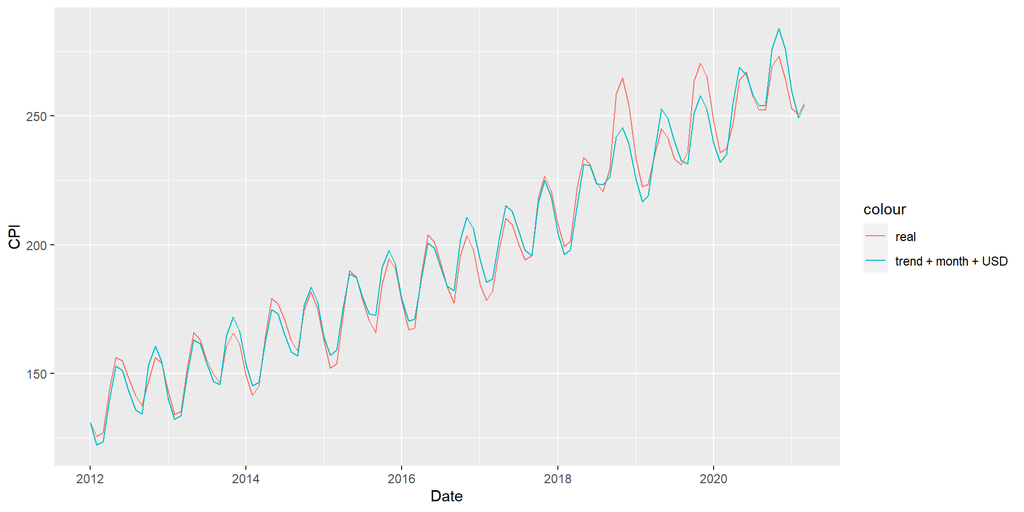

```r
EVDSdata[,pred_trend_month_USD:=predict(fit3,EVDSdata)]

ggplot(EVDSdata,aes(x= Date)) +
  geom_line(aes(y=CPI,color='real')) +
  geom_line(aes(y= pred_trend_month_USD, color='trend + month + USD'))
```

You can see there is upgrade in our prediction curve.

### Adding Other Data Series into the Model

Now, I want to add all the series that I take from EVDS database into model. After seeing the summary of the model, I can decide to whether keep the regressors in the model or not.

```r
fit4 = lm(CPI~trend + mon + USD + Interest + Clothing + CCI, data= EVDSdata)
summary(fit4)
```

```
##
## Call:
## lm(formula = CPI ~ trend + mon + USD + Interest + Clothing +
##     CCI, data = EVDSdata)
##
## Residuals:
##      Min       1Q   Median       3Q      Max
## -12.1981  -3.8649   0.1615   3.0284  14.7282
##
## Coefficients:
##              Estimate Std. Error t value Pr(>|t|)
## (Intercept) 156.27488   27.08049   5.771 1.01e-07 ***
## trend         0.87963    0.06483  13.568  < 2e-16 ***
## monAug       -7.08648    2.67579  -2.648 0.009487 **
## monDec        7.94006    2.69879   2.942 0.004105 **
## monFeb      -16.32926    2.58790  -6.310 9.09e-09 ***
## monJan       -7.08793    2.58158  -2.746 0.007238 **
## monJul        1.05487    2.65293   0.398 0.691809
## monJun        9.85431    2.68142   3.675 0.000395 ***
## monMar      -15.38058    2.57538  -5.972 4.14e-08 ***
## monMay       12.63667    2.65957   4.751 7.24e-06 ***
## monNov       15.14164    2.78714   5.433 4.35e-07 ***
## monOct        8.58711    2.93744   2.923 0.004339 **
## monSep       -9.27021    3.05329  -3.036 0.003100 **
## USD           5.04961    1.36309   3.705 0.000357 ***
## Interest      0.44311    0.13044   3.397 0.001000 **
## Clothing     -0.22147    0.26314  -0.842 0.402120
## CCI          -0.13438    0.18626  -0.722 0.472389
## ---
## Signif. codes:  0 '***' 0.001 '**' 0.01 '*' 0.05 '.' 0.1 ' ' 1
##
## Residual standard error: 5.601 on 94 degrees of freedom
## Multiple R-squared:  0.9841, Adjusted R-squared:  0.9814
## F-statistic: 362.9 on 16 and 94 DF,  p-value: < 2.2e-16
```

Interest Rates have a significant importance in the model with 2 stars. However, `Clothing` and `CCI` data series are not important in our model. Therefore, I update my model with only using `Interest`.

```r
fit5 = lm(CPI~trend + mon + USD + Interest , data= EVDSdata)
summary(fit5)
```

```
##
## Call:
## lm(formula = CPI ~ trend + mon + USD + Interest, data = EVDSdata)
##
## Residuals:
##      Min       1Q   Median       3Q      Max
## -11.2638  -3.9581   0.4188   2.9109  14.7408
##
## Coefficients:
##              Estimate Std. Error t value Pr(>|t|)
## (Intercept) 118.52775    2.61526  45.322  < 2e-16 ***
## trend         0.83444    0.05259  15.867  < 2e-16 ***
## monAug       -7.53745    2.64437  -2.850 0.005345 **
## monDec        7.81432    2.64664   2.953 0.003962 **
## monFeb      -15.96162    2.57721  -6.193 1.46e-08 ***
## monJan       -7.14787    2.57898  -2.772 0.006700 **
## monJul        0.72483    2.64366   0.274 0.784538
## monJun        9.32371    2.64285   3.528 0.000645 ***
## monMar      -15.39362    2.57711  -5.973 3.93e-08 ***
## monMay       12.26170    2.64241   4.640 1.10e-05 ***
## monNov       14.39751    2.64758   5.438 4.10e-07 ***
## monOct        7.84374    2.65057   2.959 0.003884 **
## monSep      -10.36379    2.65007  -3.911 0.000172 ***
## USD           6.41555    0.93396   6.869 6.43e-10 ***
## Interest      0.42078    0.11669   3.606 0.000496 ***
## ---
## Signif. codes:  0 '***' 0.001 '**' 0.01 '*' 0.05 '.' 0.1 ' ' 1
##
## Residual standard error: 5.605 on 96 degrees of freedom
## Multiple R-squared:  0.9837, Adjusted R-squared:  0.9813
## F-statistic: 414.1 on 14 and 96 DF,  p-value: < 2.2e-16
```

It has a very small decrease in the R-squared value but this is not important.

Now time to do prediction with our new model.

```r
EVDSdata[,pred_trend_month_USD_Interest:=predict(fit5,EVDSdata)]
```

And plot it

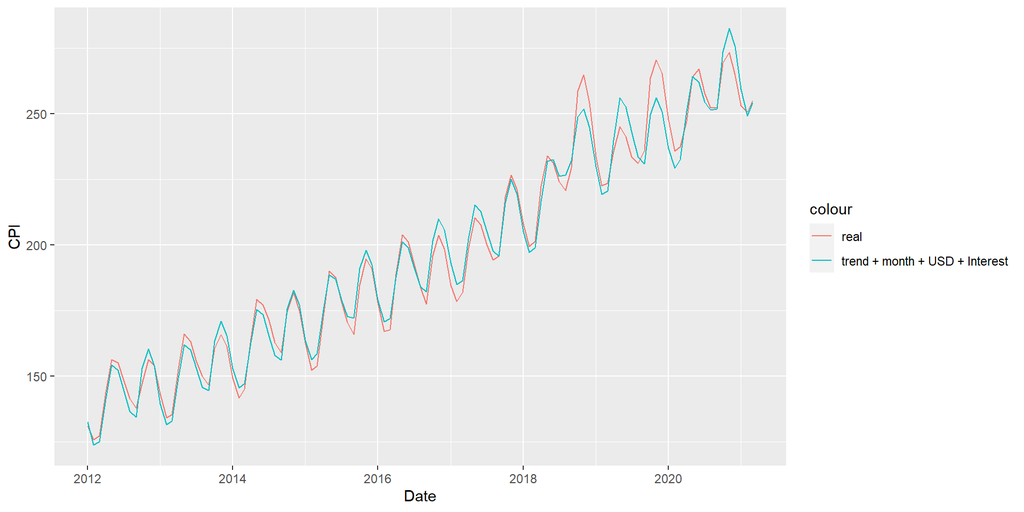

```r
ggplot(EVDSdata,aes(x= Date)) +
  geom_line(aes(y=CPI,color='real')) +
  geom_line(aes(y= pred_trend_month_USD_Interest, color='trend + month + USD + Interest'))
```

We have a better prediction curve but we still have some mispredictions.

### Lagged Variables

One more time we call `checkresiduals` function to see whether we have correlation between lags or not.

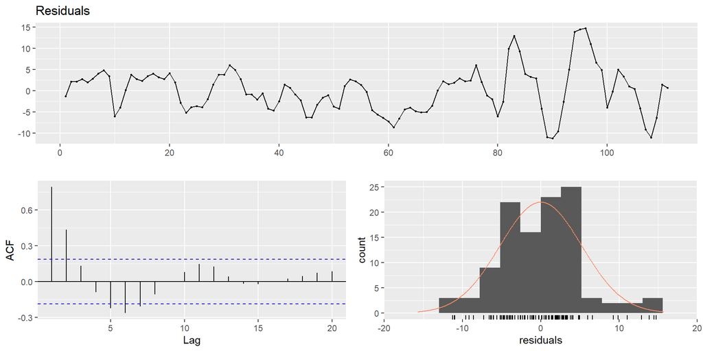

```r
checkresiduals(fit5$residuals)
```

We can see that lag 1 and lag 2 have a significant correlation. Therefore, I added lagged variables for both lag1 and lag2.

```r
EVDSdata[,lag1:=shift(residuals(fit5),1)]
EVDSdata[,lag2:=shift(residuals(fit5),2)]
```

I added residuals lag into my data table as `lag1` and `lag2`. From their importance in the model, I can extract one or both of them from the model.

Now, I can build one more model with using these lagged variables.

```r
fit6 = lm(CPI~trend + mon + USD + Interest  + lag1 + lag2 , data= EVDSdata)
summary(fit6)
```

```
##
## Call:
## lm(formula = CPI ~ trend + mon + USD + Interest + lag1 + lag2,
##     data = EVDSdata)
##
## Residuals:
##     Min      1Q  Median      3Q     Max
## -7.6080 -1.4439 -0.0044  1.4495  9.2269
##
## Coefficients:
##              Estimate Std. Error t value Pr(>|t|)
## (Intercept) 117.97764    1.38465  85.204  < 2e-16 ***
## trend         0.83460    0.02952  28.274  < 2e-16 ***
## monAug       -7.57564    1.39755  -5.421 4.75e-07 ***
## monDec        7.77302    1.39888   5.557 2.66e-07 ***
## monFeb      -16.40147    1.40117 -11.706  < 2e-16 ***
## monJan       -7.03540    1.39940  -5.027 2.44e-06 ***
## monJul        0.70085    1.39729   0.502    0.617
## monJun        9.29873    1.39678   6.657 1.99e-09 ***
## monMar      -15.41295    1.36197 -11.317  < 2e-16 ***
## monMay       12.21223    1.39646   8.745 9.96e-14 ***
## monNov       14.34196    1.39930  10.249  < 2e-16 ***
## monOct        7.77237    1.40089   5.548 2.76e-07 ***
## monSep      -10.42875    1.40063  -7.446 5.03e-11 ***
## USD           6.38288    0.51370  12.425  < 2e-16 ***
## Interest      0.45895    0.06260   7.331 8.63e-11 ***
## lag1          1.20207    0.08874  13.545  < 2e-16 ***
## lag2         -0.51194    0.08967  -5.709 1.38e-07 ***
## ---
## Signif. codes:  0 '***' 0.001 '**' 0.01 '*' 0.05 '.' 0.1 ' ' 1
##
## Residual standard error: 2.962 on 92 degrees of freedom
##   (2 observations deleted due to missingness)
## Multiple R-squared:  0.9954, Adjusted R-squared:  0.9946
## F-statistic:  1246 on 16 and 92 DF,  p-value: < 2.2e-16
```

From summary, we can see that both lagged variables have very high importance in our model so there is no need to extract lagged variables from the model.

Let us see one more time whether our model has correlation between lags or not with using `checkresiduals` function.

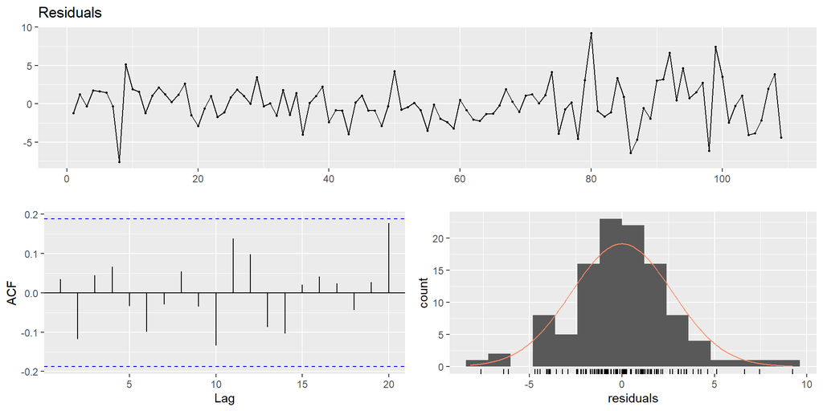

```
##
##  Breusch-Godfrey test for serial correlation of order up to 20
##
## data:  Residuals
## LM test = 19.162, df = 20, p-value = 0.5113
```

```r
checkresiduals(fit6)
```

With using lagged variables we solved correlation problem in our model.

Now, it is time to do prediction.

```r
EVDSdata[,pred_trend_month_USD_Interest_lags:=predict(fit6,EVDSdata)]
```

And plot it:

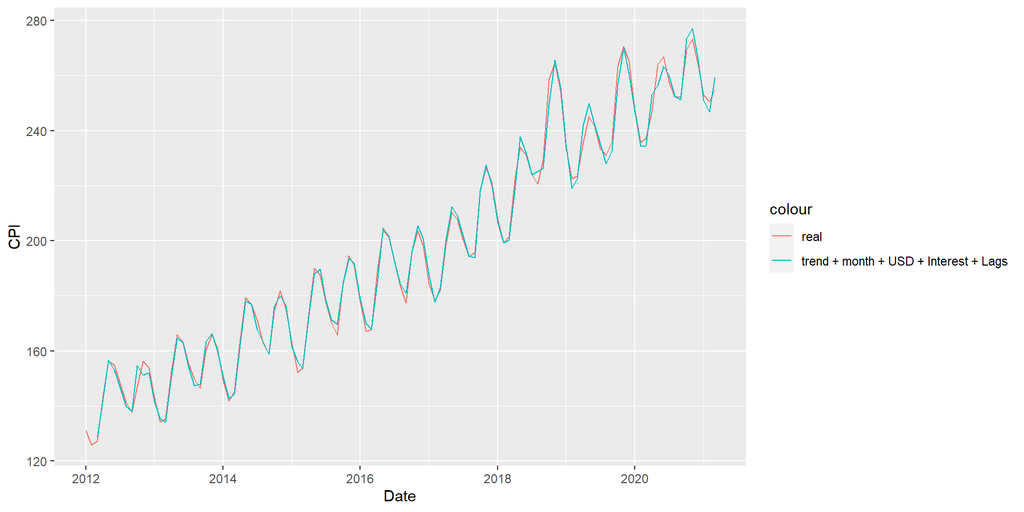

```r
ggplot(EVDSdata,aes(x= Date)) +
  geom_line(aes(y=CPI,color='real')) +
  geom_line(aes(y=pred_trend_month_USD_Interest_lags , color='trend + month + USD + Interest + Lags'))
```

As we can see clearly from plot, we have very nice predictions in the model.

We could jump into forecast step now.

### Forecast

To make forecast, I will going to put one more observation in my data table. Update its date, month and other regressor values.

```r
EVDSdata <- rbind(EVDSdata,data.table(Date = as.Date("2021-04-01")), fill=T)

EVDSdata$trend[112]= as.numeric(112)
EVDSdata$mon[112]= as.character("Apr")

lag1_last <- EVDSdata$lag1[111]
EVDSdata$lag1[112] = lag1_last

lag2_last <- EVDSdata$lag1[110]
EVDSdata$lag2[112] = lag2_last
```

Becasuse I do not know regressor values for the future. I am going to use mean of last three values of the regressors.

```r
interest_last_3 <- mean(EVDSdata[109:111]$Interest)
EVDSdata$Interest[112]= interest_last_3

USD_last_3 <- mean(EVDSdata[109:111]$USD)
EVDSdata$USD[112]= USD_last_3
```

Now final prediction for April 2021 is

```r
EVDSdata[is.na(CPI)==T,CPI:=predict(fit6,EVDSdata[is.na(CPI)==T])]
print(EVDSdata$CPI[112])
```

```
## [1] 273.8842
```

### Conclusion

What we did in this forecast process is that adding linear trend, month for seasonality, USD and Interest rates as regressors, and lagged variables in our model.

In our model we do not have any correlation between residuals and R-squared value are high enough so there is no restriction for us to do our final forecast.

We did our final forecast with using mean of last 3 USD and Interest Rate variables.

Finally, we found a forecast for April 2021 which is 273.88 while the actual data for April 2021 is 274.23.

This result is pretty satisfying.

#### References

[Central Bank of Turkey Data Center](https://evds2.tcmb.gov.tr/index.php?/evds/serieMarket)